# Two Samples about SLR

Xinyi (Serene) Zhang

9/28/2019

The famous Hooke’s law describes the relationship between a spring’s length and the weight it’s carrying.

#### Q7

*What would be considered the response variable here?*

#### Q8

*Please use least squares to fit a SLR to this data under the model. Reprot thr fitted coefficients.*

```r
Hooke<-data.frame(weight=c(0,2,4,6,8,10),length=c(439.0,439.12,439.21,439.31,439.40,439.50))
lm1<-lm(length~weight,data=Hooke)
summary(lm1)
```

```
##
## Call:
## lm(formula = length ~ weight, data = Hooke)
##
## Residuals:
##         1         2         3         4         5         6
## -0.010952  0.010762  0.002476  0.004190 -0.004095 -0.002381
##
## Coefficients:
##              Estimate Std. Error  t value Pr(>|t|)
## (Intercept) 4.390e+02  6.076e-03 72254.92  < 2e-16 ***
## weight      4.914e-02  1.003e-03    48.98 1.04e-06 ***
## ---
## Signif. codes:  0 '***' 0.001 '**' 0.01 '*' 0.05 '.' 0.1 ' ' 1
##
## Residual standard error: 0.008395 on 4 degrees of freedom
## Multiple R-squared:  0.9983, Adjusted R-squared:  0.9979
## F-statistic:  2399 on 1 and 4 DF,  p-value: 1.04e-06
```

```r
lm1$coefficients
```

```
##  (Intercept)       weight
## 439.01095238   0.04914286
```

The result of lm1 etimated the model as: $y_{i}=439.011+0.049x_{i}+\epsilon_{i}$

#### Q9

*What is your best estimate (best in the term of sum of squared error) for the length of the spring when the weight is 9kg?*

```r
nw<-data.frame(weight=9,length=NA)
est1<-predict(lm1,newdata = nw)
est1
```

```
##        1
## 439.4532
```

#### Q10

*Calulated the standard error for the estimate in Q9. Wht isn’t variance a good value to descirbe the uncertainty relative to the standard error?*

```r
sigma2<-sum((lm1$residuals)^2)/4
sigma2
```

```
## [1] 7.047619e-05
```

```r
x<-Hooke$weight
sum_square_x<-sum((x-mean(x))^2)
sum_square_x
```

```
## [1] 70
```

```r
theo_var<-sigma2*(1/6+(9-mean(x))^2/sum_square_x)
SE<-sqrt(theo_var)
SE
```

```
## [1] 0.005277772
```

Variance is about $(x_{i}-\bar{x})^2$, the units of variance is not the same with other statistics. In that case, standard error is a better choice becasue it is more convienient to compute and compare with other statistics.

#### Q11

*Imagine you are working with Hooke, the physicist. He wants you to show, graphically, the relationship between the spring length and the weight along with different uncertainty values.*

```r
plot(x,Hooke$length,xlab = "units")
abline(lm1,col="red",lty=30)
pred<-lm1$coefficients[1]+lm1$coefficients[2]*x
theo_var<-sigma2*(1/6+(x-mean(x))^2/sum_square_x)
theo_var
```

```
## [1] 3.691610e-05 2.080726e-05 1.275283e-05 1.275283e-05 2.080726e-05
## [6] 3.691610e-05
```

```r
pred_lower<-pred+2*sqrt(theo_var)
pred_lower
```

```
## [1] 439.0231 439.1184 439.2147 439.3130 439.4132 439.5145
```

```r
pred_upper<-pred-2*sqrt(theo_var)
pred_upper
```

```
## [1] 438.9988 439.1001 439.2004 439.2987 439.3950 439.4902
```

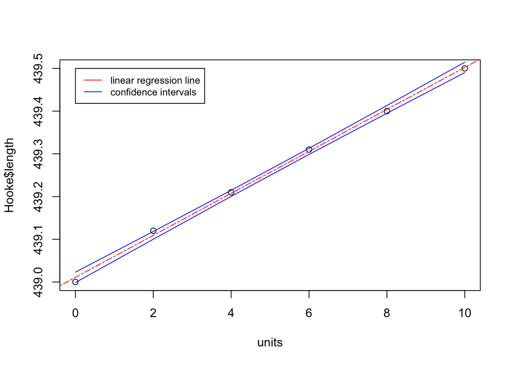

```r
lines(x,pred_lower,col="blue")
lines(x,pred_upper,col="blue")
legend(0,439.5,legend = c("linear regression line","confidence intervals"),col=c("red","blue"),lty=1, cex=0.8)
```

From Kaggle, there’s a dataset on the wine ratings from Wine Enthusiast. We are going to predict the wine ratings, ie. the points, based on a feature we will generate from the text. To create our feature, here is a list of some common adjectives for wine: “fruit”, “aromas”,“acidity”, “finish”, “tannins”, “cherry”, “black”, “ripe”, “red”, “rich”, “fresh”, “oak”, “spice”, “dry”, “berry”, “full”, “plum”, “apple”, “soft”, “sweet”.

#### Q12

*Choose 10 adjectives randomly from the list above using a pseudo-random number generator like sample() in R and report which adjectives you got. (In real life, this could be a good baseline against expert marketers).* *Let’s create a feature for wine that equals to the total count of the chosen 10 keywords within the descripttion.*

```r
set.seed(0)
library(purrr)
wine<-read.csv(file="hw3_filtered_wine_reviews.csv")
adj<-c( "fruit", "aromas",
"acidity", "finish", "tannins", "cherry", "black", "ripe", "red", "rich", "fresh", "oak", "spice", "dry", "berry", "full", "plum", "apple", "soft", "sweet")
subadj<-sample(adj,10,replace=F)
subadj
```

```
##  [1] "dry"    "finish" "black"  "fruit"  "aromas" "spice"  "apple"  "fresh"
##  [9] "full"   "berry"
```

```r
descrip<-tolower(wine$description)%>%   replace(gsub('[^a-zA-Z]+',' '   ,"H0l1o"),NA)%>%strsplit(split = " |\\,|\\.")%>%na.omit()
```

```r
new_point<-c()
for(i in 1:129971){
  new_point[i]=length(intersect(unlist(descrip[i]),subadj))
}
```

#### Q13

*Now fit the linear regression by fitting points to this new feature. Report the coefficients you get for your regression line.*

```r
lm2<-lm(wine$points~new_point)
summary(lm2)
```

```
##
## Call:
## lm(formula = wine$points ~ new_point)
##
## Residuals:
##     Min      1Q  Median      3Q     Max
## -8.8393 -2.1580 -0.3283  2.3310 11.8420
##
## Coefficients:
##              Estimate Std. Error t value Pr(>|t|)
## (Intercept) 88.157996   0.014541 6062.89   <2e-16 ***
## new_point    0.170338   0.006987   24.38   <2e-16 ***
## ---
## Signif. codes:  0 '***' 0.001 '**' 0.01 '*' 0.05 '.' 0.1 ' ' 1
##
## Residual standard error: 3.033 on 129969 degrees of freedom
## Multiple R-squared:  0.004552,   Adjusted R-squared:  0.004545
## F-statistic: 594.4 on 1 and 129969 DF,  p-value: < 2.2e-16
```

```r
lm2$coefficients
```

```
## (Intercept)   new_point
##  88.1579956   0.1703381
```

The linear regression line fitted by points is$y=88.16+0.17x$

#### Q14

*Your team about to launch some marketing description of their new wine. You, unfortunately, was given the task to predict the points of the new wine will receive from WineEnthusiast. What is your prediction if the count is 3?*

```r
nw<-data.frame(points=NA,new_point=3)
est2<-predict(lm2,newdata = nw)
est2
```

```
##        1
## 88.66901
```

When the count is 3, points is estimated as 88.67.

#### Q15

*Now your boss wants to communicate our your prediction to the marketing team, which uncertainty should you report on your prediction for the new wine?*

```r
sigma2<-sum((lm2$residuals)^2)/(length(lm2$residuals)-2)
sum_square_x<-sum((new_point-mean(new_point))^2)
sum_square_x
```

```
## [1] 188419
```

```r
theo_var<-sigma2*((1+length(new_point))/length(new_point)+(3-mean(new_point))^2/sum_square_x)
SEpoint<-sqrt(theo_var)
SEpoint
```

```
## [1] 3.03284
```

```r
pred2_lower<-est2+qt(0.025,length(new_point))*SEpoint
pred2_upper<-est2+qt(0.975,length(new_point))*SEpoint
pred2_lower
```

```
##       1
## 82.7247
```

```r
pred2_upper
```

```
##        1
## 94.61332
```

The uncertainty is $SE=3.03$, and the interval would be(82.72,94.61)

#### Q16

*Please comment on why the uncertainty you chose for Q11 and Q15 are the same or different?*